# Problem Set Discussions

Albert Y. Kim

Last updated on 2017-05-15

# Problem Set 12

Load necessary packages:

```r
library(ggplot2)
library(dplyr)
library(mosaic)
library(broom)
library(nycflights13)
library(knitr)
data(flights)
data(weather)
```

## Question 1

American Airlines is concerned with the temperature and humidity recorded for its daily flight AA 59 from JFK to San Francisco, CA. In particular they want to study the relationship between temperature and humidity with humidity as the $y$ variable.

1. Create an appropriate visualization for this data.
2. Fit a linear regression and interpret
   1. The estimate of the slope
   2. The 95% confidence interval for the slope
   3. The conclusion of the hypothesis test using non-statisticial language
3. Visualize the *residuals* and comment on their distribution

## Discussion

Recall from Midterm II Question 2.d), that to join `flights` and `weather`, we have to join by `year`, `month`, `day`, `hour`, and `origin`:

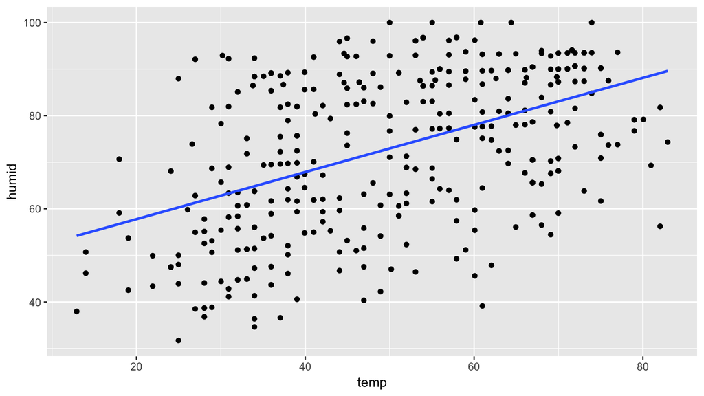

```r
flights_with_weather <- flights %>%
  filter(carrier == "AA" & flight == 59) %>%
  left_join(weather, by=c("year","month","day","hour","origin"))

ggplot(flights_with_weather, aes(x=temp, y=humid)) +
  geom_point() +
  geom_smooth(method="lm", se=FALSE)
```

It appears there is a positive relationship.

```r
# Fit regression
model <- lm(humid~temp, data=flights_with_weather)

# Inspect regression output table
model_table <- model %>%
  tidy(conf.int = TRUE)
model_table %>%
  kable(digits=3)
```

| term | estimate | std.error | statistic | p.value | conf.low | conf.high |
| --- | --- | --- | --- | --- | --- | --- |
| (Intercept) | 47.648 | 2.570 | 18.537 | 0 | 42.594 | 52.703 |
| temp | 0.506 | 0.049 | 10.433 | 0 | 0.411 | 0.601 |

Looking at the residuals AKA **lack-of-fit**, they appear centered at 0 and roughly normally distributed. Thus our above confidence intervals and p-values have valid interpretation!

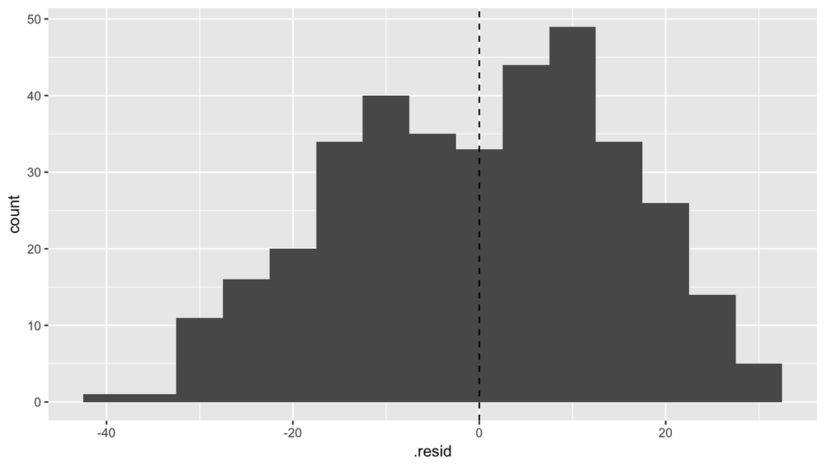

```r
mode_points <- model %>%
  augment()
ggplot(mode_points, aes(x=.resid)) +
  geom_histogram(binwidth = 5) +
  geom_vline(xintercept=0, linetype="dashed")
```

# Problem Set 11

Load necessary packages:

```r
library(ggplot2)
library(dplyr)
library(mosaic)
library(fivethirtyeight)
data(congress_age)
set.seed(76)
```

## Scenario:

You are charged with studying the average age of members of congress (House of Representatives and Senate) at the start of their term for all sessions of Congress between:

- The [80th United States Congress](https://en.wikipedia.org/wiki/80th_United_States_Congress) from January 3, 1947 to January 3, 1949
- The [113th United States Congress](https://en.wikipedia.org/wiki/113th_United_States_Congress) from January 3, 2013 to January 3, 2015

In particular, you are interested in answering the following question: comparing just the 80th and the 113th sessions, are members of congress on average younger now (in 2013) or then (in 1947)?

However, researching birthdays and age at the start of the terms for all 18635 members of congress between the 80th and 113th sessions of Congress is painstakingly boring work. So you decide to compute ages only for a random sample of members of congress instead.

## Question 1: CI for Difference of Population Means

Run these two lines to get your random sample of

- $n_{80}$ = 40 members of congress from the 80th session
- $n_{113}$ = 35 members of congress from the 113th session

```r
congress_age_80 <- congress_age %>%
  filter(congress == 80) %>%
  sample_n(40)
congress_age_113 <- congress_age %>%
  filter(congress == 113) %>%
  sample_n(35)
congress_80_and_113 <- bind_rows(congress_age_80, congress_age_113)
```

#### a) EDA

Create one plot of exploratory data analysis.

Note here we convert the variable `congress` from a numerical variable to a categorical one by using `as.factor()`. It appears members of congress are older now:

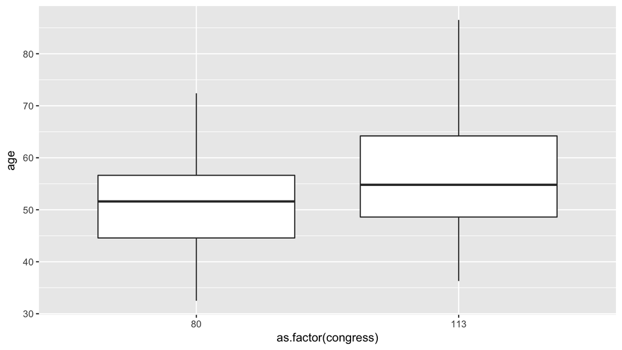

```r
ggplot(data=congress_80_and_113, aes(x=as.factor(congress), y=age)) +
  geom_boxplot()
```

#### b) 95% CI

Create a 95% confidence interval for $\mu_{80}-\mu_{113}$, the true **population difference in means** of the average age in the 80th session minus the average age in the 113th session. **Hint**: The formula to approximate the standard error for a difference of means $\overline{x}_1 - \overline{x}_2$ is

$$SE_{\overline{x}_1 - \overline{x}_2} = \sqrt{
\left( \frac{(n_1-1)s_1^2 + (n_2-1)s_2^2}{n_1+n_2-2} \right)
\left( \frac{1}{n_1} + \frac{1}{n_2} \right)
}$$

Note that the formula involves $s^2$ and not $s$, the sample variance = the sample standard deviation squared.

```r
n1 <- 40
n2 <- 35
s1 <- sd(congress_age_80$age)
s2 <- sd(congress_age_113$age)
SE <- sqrt(  ((n1 -1)*s1^2 + (n2 -1)*s2^2)/(n1+n2-2) * (1/n1 + 1/n2)  )
SE
```

```
## [1] 2.537323
```

The point estimate $\overline{x}_{80} - \overline{x}_{113}$ based on our results below is 51.54 - 55.82 = -4.28

```r
congress_80_and_113 %>%
  group_by(congress) %>%
  summarise(avg_age = mean(age))
```

| congress | avg_age |
| --- | --- |
| 80 | 51.5475 |
| 113 | 55.8200 |

So the 95% confidence interval is

```r
c(-4.28 - 2*SE, -4.28 + 2*SE)
```

```
## [1] -9.3546451  0.7946451
```

**Your Answers**:

- My confidence interval is: (-9.35, 0.79)
- Since the confidence interval includes 0, the data in the sample is not suggestive of a meaningful difference in ages.

# Problem Set 10

## Question 1:

Answer the question “Did Econ majors do better on the intro stats final than non-Econ majors?” using the `grades.csv` data set from Lec28. Note: save the file `grades.csv` in the same folder/directory as `PS-10.Rmd`.

#### Hypothesis Test Setup

We have

- $H_0: \mu_E - \mu_O = 0$ vs
- $H_A: \mu_E - \mu_O > 0$

or equivalently

- $H_0: \mu_O - \mu_E = 0$ vs
- $H_A: \mu_O - \mu_E < 0$

Note we are dealing with a *one-sided* alternative!

#### Observed Test Statistic

First, we compute the observed test statistic, noting carefully that it’s the mean of the other students minus the mean of the econ students: $\overline{x}_O - \overline{x}_E$:

```r
set.seed(76)
grades <- read_csv("grades.csv")
mean(final ~ major, data=grades)
```

```
## Economics     Other
## 0.7599581 0.6823899
```

```r
mean(final ~ major, data=grades) %>% diff()
```

```
##       Other
## -0.07756813
```

```r
observed_diff <- mean(final ~ major, data=grades) %>% diff()
```

It seems that Econ majors did 7.76% better, but is this difference **statistically** significant?

#### Null Distribution

Next, we construct the null distribution of the difference in means *assuming* there is no true difference. Note when computing `difference`, we make sure that we subtract in the correct order:

```r
simulations <- do(10000) * mean(final ~ shuffle(major), data=grades)
simulations <- simulations %>%
  mutate(difference=Other-Economics)
```

#### Comparison

Finally, we compare the

- observed test statistic
- null distribution of the test statistic

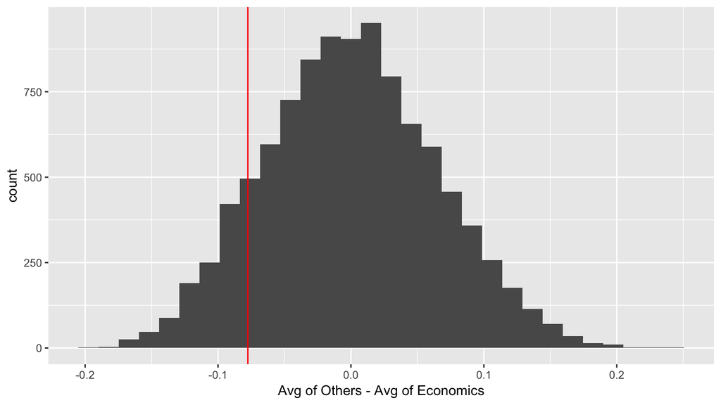

```r
ggplot(data=simulations , aes(x=difference)) +
  geom_histogram() +
  labs(x="Avg of Others - Avg of Economics") +
  geom_vline(xintercept = observed_diff, col="red")
```

The observed difference of -0.0776 = -7.76% doesn’t seem all that extreme. i.e. it seems plausible

#### p-Value

In this case, since $H_A: \mu_O - \mu_E < 0$, more extreme means *more negative*!

So the p-value is the proportion of time

```r
simulations %>%
  mutate(more_extreme = difference < -0.0776) %>%
  summarise(n_more_extreme = sum(more_extreme))
```

```
## [1] 1159
```

$$p-\mbox{Value} = \frac{1159+1}{10000} = 0.116.$$

## Question 2:

**To be handed in on paper**: Say we have a population where the racial breakdown of the juror pool (registered voters) is:

| Race | Caucasian | African-American | Latino | Other | Total |
| --- | --- | --- | --- | --- | --- |
| Proportion | 72% | 7% | 12% | 9% | 100% |

Social scientists want to know if there is a racial bias as to who gets selected for jury duty in this population. They collect data on three scenarios of jury selection, where each time 100 potential jurors are selected from the population.

| Scenario | Caucasian | African-American | Latino Count | Other Count | Total Count |
| --- | --- | --- | --- | --- | --- |
| A | 72 | 7 | 12 | 9 | 100 |
| B | 0 | 0 | 100 | 0 | 100 |
| C | 75 | 6 | 11 | 8 | 100 |

1. What is $H_0$ and $H_A$ for this study?
2. What is the test statistic for this study? Write it out in general.
3. What is the null distribution for this study?
4. For each of these three scenarios individually, use the chi-squared test with $\alpha=0.1$ to answer the question “is there racial bias in jury selection?” being sure to:
   1. Compute the *observed test statistic*
   2. Draw the null distribution and indicate the observed test statistic
   3. Compute the p-value. [Hint](https://beta.rstudioconnect.com/connect/#/apps/2719/access).
   4. Complete the test
   5. Write down your conclusion in non-statistical language

#### 1. Hypothesis Test Setup

- $H_0$: the selection was done randomly
- $H_A$: the selection was done with racial bias

Note: chi-square tests do **not** involve a population parameter

#### 2. Test Statistic

The test statistic in general is the **chi-squared test statistic**:

$$\chi^2 = \sum_{i=1}^k \frac{(\mbox{Observed Count}_i - \mbox{Expected Count}_i)^2}{\mbox{Expected Count}_i}$$
Note that when we observe exactly what we expect, the numertor is 0. So:

- Smaller values of $\chi^2$ indicates more evidence in favor of $H_0$
- Larger values of $\chi^2$ indicates more evidence in favor of $H_A$

In our case, we have $k=4$ groups; each of the 4 ethnic groups, so

$$\chi^2 = \frac{(\mbox{Observed Caucasian Count} - \mbox{Expected Caucasian Count})^2}{\mbox{Expected Caucasian Count}} + \ldots + \frac{(\mbox{Observed Other Count} - \mbox{Expected Other Count})^2}{\mbox{Expected Other Count}}$$

#### 3. Null Distribution

In general, the null distribution is not the normal distribution but rather the $\chi^2$ distribution with $k-1$ degrees of freedom. Note: its values are from 0 to $\infty$. In our case, since $k=4$, the degrees of freedom are $4-1=3$

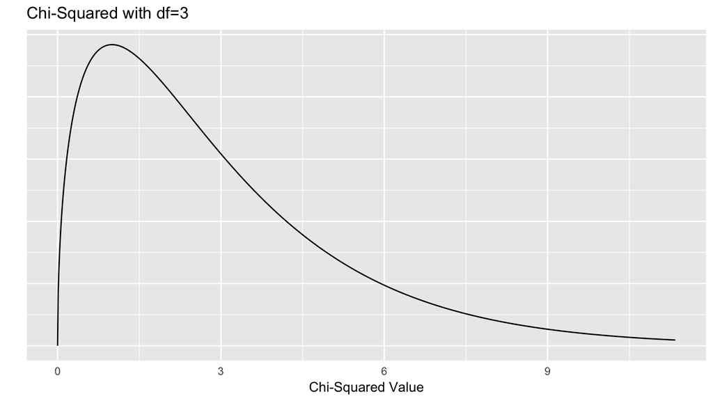

#### 4. Each Scenario

**Scenario 1:** In this case, the observed test statistic is

```r
observed <- c(72, 7, 12, 9)
expected <- c(72, 7, 12, 9)
sum((observed-expected)^2/expected)
```

```
## [1] 0
```

$$\chi^2 = \frac{(72-72)^2}{72} + \frac{(7-7)^2}{7} + \frac{(12-12)^2}{12} + \frac{(9-9)^2}{9} = 0$$

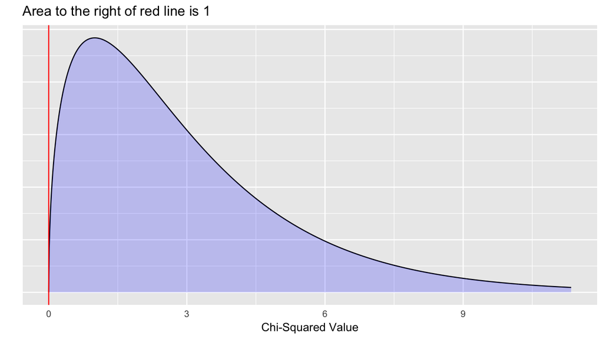

Since the p-value is 1, for ANY $\alpha$ we’d have p-value $> \alpha$, so we do not reject. Of course we do not reject the hypothesis of no racial bias; we observed exactly what we’d expect!

**Scenario 2:** In this case, the observed test statistic is

```r
observed <- c(0, 0, 100, 0)
expected <- c(72, 7, 12, 9)
sum((observed-expected)^2/expected)
```

```
## [1] 733.3333
```

$$\chi^2 = \frac{(0-72)^2}{72} + \frac{(0-7)^2}{7} + \frac{(100-12)^2}{12} + \frac{(0-9)^2}{9} = 733.3333$$

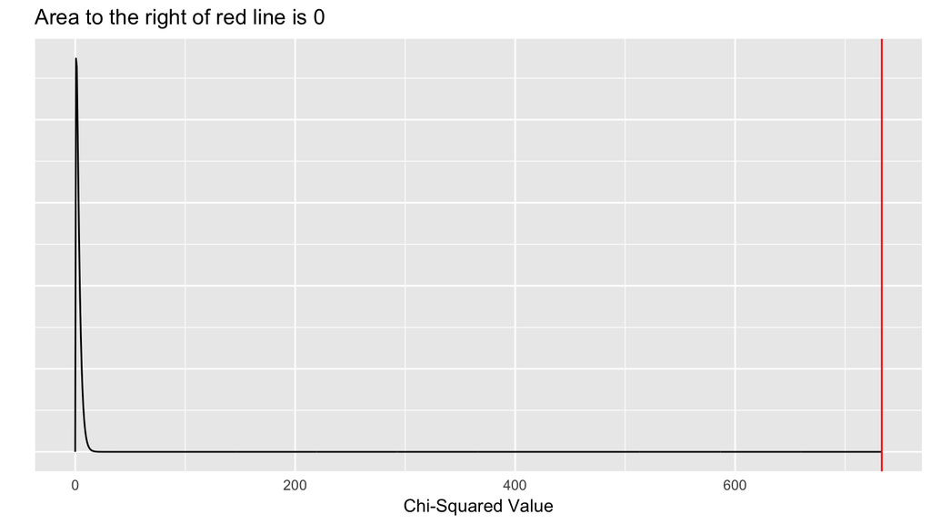

The p-value is 0; this is **very** extreme. So for ANY $\alpha$ we’d have p-value $< \alpha$, so we reject $H_0$ in favor of $H_A$. Of course we reject the hypothesis of no racial bias; how could we have 100 out of 100 Latinos when they are only 12% of the population?

**Scenario 3:** Now things aren’t as clear cut!

```r
observed <- c(75, 6, 11, 8)
expected <- c(72, 7, 12, 9)
sum((observed-expected)^2/expected)
```

```
## [1] 0.4623016
```

$$\chi^2 = \frac{(75-72)^2}{72} + \frac{(6-7)^2}{7} + \frac{(11-12)^2}{12} + \frac{(8-9)^2}{9} = 0.4623016$$

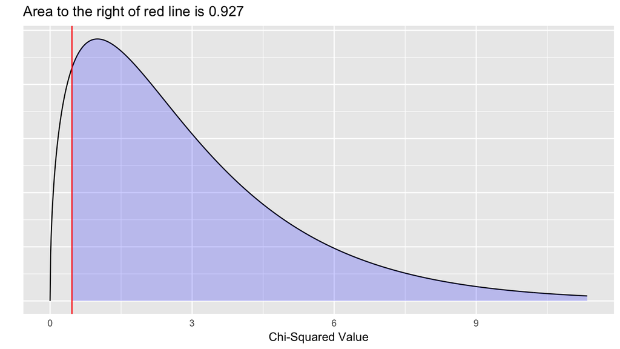

The p-value 0.927 is $> \alpha=0.1$, so we do not reject $H_0$. In other words **while there still may exist racial discrimination, the data/evidence we observed in Scenario 3 doesn’t support this**.

# Problem Set 09

## Question 1:

### Code

Create the visualization from Question 3.b) of Midterm II:

**Answer**:

- We only care about the 4 aces out of 52. Let `1` denote the 4 aces, and `0` denote the remaining 48 cards. Note `rep()` is a command to repeat a certain value the specified number of times.
- We sample 5 cards *without* replacement

We plot the results:

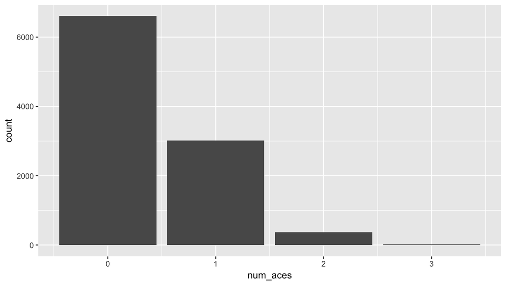

```r
deck <- c(rep(1, times=4), rep(0, times=48))
simulation <- do(10000) * resample(deck, size=5, replace=FALSE)
simulation <- simulation %>%
  mutate(num_aces = V1 + V2 + V3 + V4 + V5)
ggplot(simulation, aes(x=num_aces)) +
  geom_bar()
```

```r
simulation %>%
  group_by(num_aces) %>%
  summarise(count=n())
```

| num_aces | count |
| --- | --- |
| 0 | 6601 |
| 1 | 3011 |
| 2 | 368 |
| 3 | 20 |

### Analysis

1. What is the probability of getting a pair of aces?
2. What is the probability of getting one or more aces?

**Answer**:

1. This occured 368 out of 10000 times, so roughly 0.0368 = 3.68% of the time.
2. No aces occured 6601 out of 10000 times, so roughly 0.6601 = 66.01%. This getting 1 or more is 1-0.6601=0.3399 = 33.99%.

**Note**:

- How rare getting 4 aces is! If you’re playing poker and get 4 aces, bet your house!
- This question can also be solved mathematically using the [hypergeometric distribution](https://en.wikipedia.org/wiki/Hypergeometric_distribution), which gives the *exact* quantity we could repeat the above experiment infinitely. So the probability of picking `x=2` aces out of `k=5` cards sampled without replacement, from a deck with `m=4` total aces and `n=48` other cards is *exactly*:

```r
dhyper(x=2, m=4, n=48, k=5)
```

```
## [1] 0.03992982
```

Our simulated answer is pretty close from part 1!

## Question 2:

### Code

Do Question 2.d) from Midterm II

1. by joining `flights` and `weather` by year, month, day, hour
2. by joining `flights` and `weather` by year, month, day, hour, and origin as per the diagram at the start of Question 2.

**Hint**: Google is a programmer’s best friend.

**Answer**: In order to join by multiple variables, we use the `c()` for “concatenate” function in the `by` argument:

```r
flights %>%
  left_join(weather, by=c("year", "month", "day", "hour")) %>%
  filter(month==7) %>%
  summarise(mean_humid = mean(humid, na.rm=TRUE))
```

```
## [1] 65.87282
```

```r
flights %>%
  left_join(weather, by=c("year", "month", "day", "hour", "origin")) %>%
  filter(month==7) %>%
  summarise(mean_humid = mean(humid, na.rm=TRUE))
```

```
## [1] 66.18039
```

### Analysis

Why are the answers different?

**Answer**: Because the data are linked for a specific time *for each airport*. For example the temperature at Newark may be different than at JFK. If we don’t make it absolutely clear that the join needs to happen along `origin` as well, we may end up joining weather at a time at one airport with flight information for the same time *but at a different airport*.

# Problem Set 08

## Question 1:

You are going to compute via simulation and not via mathematical formulas, the **probability distribution** of all possible sums of two die rolls: for all possible sums of rolling two dice (x=2, x=3, …, x=12), we compute Probability(sum of rolling two dice = x).

1. Write code that will simulate die rolls and manipulate the output so that you end up with a data frame `probs` with 11 rows and 2 columns:
   - `sum`: each value of the possible sum of rolling two dice
   - `probability`: the observed probability of each value of `sum`
2. Once you’ve fully created it, change the `eval=FALSE` to `eval=TRUE` in the starting line of the code block below to have the plot get generated.
3. Note even though `sum` is a numerical variable, we’ll treat it as a categorical variable by using the `as.factor()` command and using a bar chart. It looks cleaner this way.

**Solution**:

Key points to understand:

- We first simulate sums of two die rolls. These are the possible outcomes: 2, 3, 4, …, 11 or 12.
- We then count the number of times each outcome occurred using `n()` and not `sum()`
- We convert the counts into to proportion by dividing by the number of simulations we did: 10000

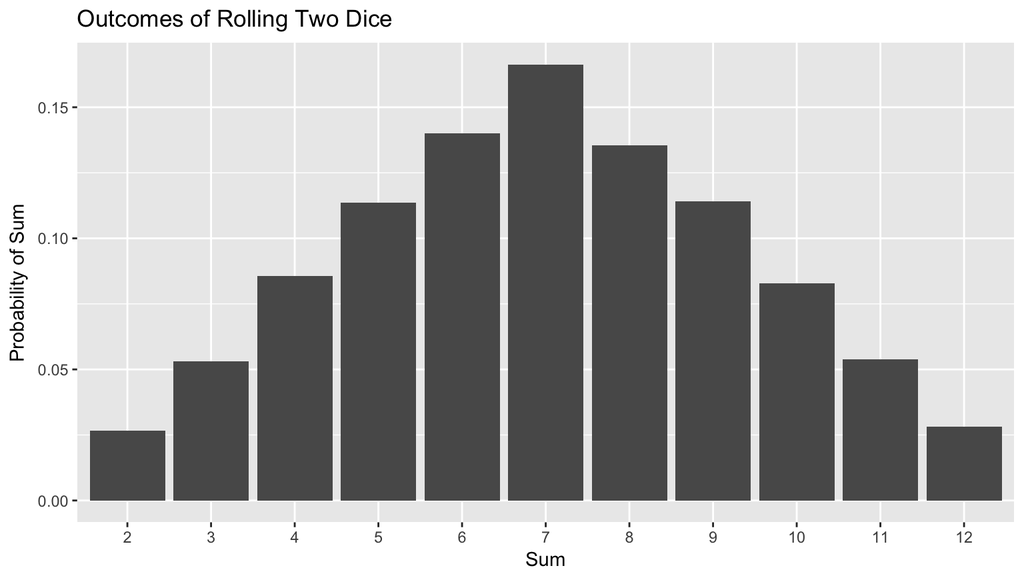

```r
# Write your code to create the data frame probs here:
die <- c(1:6)
two_die_rolls <- do(10000) * resample(die, size=2, replace = TRUE)

probs <- two_die_rolls %>%
  mutate(sum=V1+V2) %>%
  group_by(sum) %>%
  summarise(count=n()) %>%
  mutate(probability=count/10000)

# Suggested ggplot call. Feel free to change it:
ggplot(probs, aes(x=as.factor(sum), y=probability)) +
  geom_bar(stat="identity") +
  labs(x="Sum", y="Probability of Sum", title="Outcomes of Rolling Two Dice")
```

## Question 2:

Problem 3.20 on page 162 of the OpenIntro Textbook on “With and without replacement”. For this question, find all probabilities using R’s sampling capabilities.

**Solution**:

#### Advanced: a) and b) from text

**Starter Code**: We define a `room` and `stadium`, both half female, but with populations of size `n=10` and `n=10000`. Let `1` represent a female and `0` represent a male, so that to count the number of females we need to only `sum()` a series of `0`’s and `1`’s.

```r
room <- rep(c(1, 0), each=5)
stadium <- rep(c(1, 0), each=5000)

# Sampling with and without replacement from the room
room_sample_with_replace <- do(10000)*resample(room, size=2, replace=TRUE)
room_sample_with_replace %>%
  mutate(num_female = V1+V2) %>%
  group_by(num_female) %>%
  summarise(count=n())
```

| num_female | count |
| --- | --- |
| 0 | 2487 |
| 1 | 5039 |
| 2 | 2474 |

```r
room_sample_without_replace <- do(10000)*resample(room, size=2, replace=FALSE)
room_sample_without_replace %>%
  mutate(num_female = V1+V2) %>%
  group_by(num_female) %>%
  summarise(count=n())
```

| num_female | count |
| --- | --- |
| 0 | 2204 |
| 1 | 5543 |
| 2 | 2253 |

```r
# Sampling with and without replacement from the stadium
stadium_sample_with_replace <- do(10000)*resample(stadium, size=2, replace=TRUE)
stadium_sample_with_replace %>%
  mutate(num_female = V1+V2) %>%
  group_by(num_female) %>%
  summarise(count=n())
```

| num_female | count |
| --- | --- |
| 0 | 2492 |
| 1 | 5075 |
| 2 | 2433 |

```r
stadium_sample_with_replace <- do(10000)*resample(stadium, size=2, replace=FALSE)
stadium_sample_with_replace %>%
  mutate(num_female = V1+V2) %>%
  group_by(num_female) %>%
  summarise(count=n())
```

| num_female | count |
| --- | --- |
| 0 | 2561 |
| 1 | 4938 |
| 2 | 2501 |

Fill in the table with the results from your simulations in the code block below

[output not shown]

**Conclusion**:

- The effect of sampling with vs without replacement in the room leads to a difference of 2.7%
- The effect of sampling with vs without replacement in the stadium leads to a difference of 0.0016%

#### Advanced: c) from text

**Moral of the Story**: The larger the population, the less the difference in results between sampling with vs without replacement matter.

# Problem Set 07

## Question: `nycflights13` data

```r
# Load all pacakges necessary
library(ggplot2)
library(dplyr)
library(knitr)

# Load all data sets in nycflights
library(nycflights13)
data(flights)
data(planes)
data(airlines)
data(weather)
data(airports)
```

You are a junior analyst in the airline industry, specifically working for Virgin America. You are tasked with calculating Virgin America’s total [available seat miles](https://en.wikipedia.org/wiki/Available_seat_miles) for all flights leaving each of the three New York Metropolitan area airports separately, and comparing these figures with those of ExpressJet Airlines Inc, a close rival to your company. Available seat miles are the fundamental units of production for a passenger-carrying airline and it is a measure of capacity. You are asked for two deliverables:

1. Present these results in
   - A well-formatted and easy to read table
   - A cleanly formatted visualization
2. Give a two sentence executive summary on the comparison in available seat miles between Virgin America and ExpressJet Airlines Inc for the three NYC airports.

Please heed the “tao of data analysis” [tips](https://rudeboybert.github.io/MATH116/notes.html#lec18_-_fri_324:_the_tao_of_data_analysis) before starting.

## Deliverable 1: Table

```r
# Clean up our workspace: Reduce both the flights and planes data sets to only
# those columns and rows we need.
flights_cleaned <- flights %>%
  filter(carrier == "VX" | carrier == "EV") %>%
  select(tailnum, carrier, distance, origin)

planes_cleaned <- planes %>%
  select(tailnum, seats)

# Now we join the two by the variable "tailnum". Note, when the variable we are
# joining along has the same name in both datasets, we don't need to do:
# by = c("tailnum" = "tailnum")
flights_planes_joined <- flights_cleaned %>%
  left_join(planes_cleaned, by = "tailnum")

results <- flights_planes_joined %>%
  # Now we can compute ASM:
  mutate(seat_miles = seats * distance) %>%
  # Since we want all 6 possible origin X carrier pairs, we group by
  # those variables and THEN summarize
  group_by(origin, carrier) %>%
  summarise(total_seat_miles = sum(seat_miles)) %>%
  # While not necessary, I decide to sort in descending order of ASM
  arrange(desc(total_seat_miles))

results
```

| origin | carrier | total_seat_miles |
| --- | --- | --- |
| JFK | VX | 1632349744 |
| EWR | EV | 1465958750 |
| EWR | VX | 664331034 |
| LGA | EV | 333516285 |
| JFK | EV | 17761240 |

## Deliverable 2: Visualization

Now when it comes to plotting, recall me email from Thursday, Oct 27 referencing how to plot a `geom_bar()` when you have an explicit variable you want to map to the `y` aesthetic. You need to tell `geom_bar()` to override its default behavior and use the `y=total_seat_miles` variable by setting `geom_bar(stat="identity")`. See the code for Problem Set 05 Discussion -> Q1.c) -> second plot comparing proportions for another example.

**Note**: We don’t forget the axes labels and title!

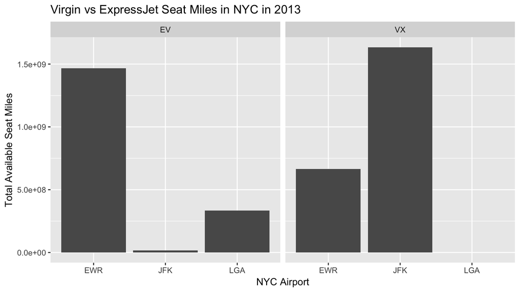

```r
ggplot(results, aes(x=origin, y=total_seat_miles)) +
  geom_bar(stat="identity") +
  facet_wrap(~carrier) +
  labs(x="NYC Airport", y="Total Available Seat Miles", title="Virgin vs ExpressJet Seat Miles in NYC in 2013")
```

My executive summary: Overall, we (as in Virgin America) have about the same capacity, but definitely spread out over different airports. We’ve got JFK covered, but definitely don’t have the capacity that ExpressJet does at Newark and La Guardia. So I suggest we target our marketing so that

- we promote our great number of options to people who tend to fly out of JFK.
- we start running ads that bad mouth ExpressJet to people who tend to fly out of Newark.

## Advanced

Once you get better at these things, you can write code super consisely. Not required for this class…

```r
flights %>%
  left_join(planes, by = "tailnum") %>%
  filter(carrier %in% c("VX", "EV")) %>%
  mutate(seat_miles = seats*distance) %>%
  group_by(origin, carrier) %>%
  summarise(total_seat_miles = sum(seat_miles)) %>%
  arrange(desc(total_seat_miles))
```

| origin | carrier | total_seat_miles |
| --- | --- | --- |
| JFK | VX | 1632349744 |
| EWR | EV | 1465958750 |
| EWR | VX | 664331034 |
| LGA | EV | 333516285 |
| JFK | EV | 17761240 |

# Problem Set 06

## Question 1: Drug Use Amongst OkCupid Users

Let’s revisit the 60,000 San Francisco OkCupid users in 2012 and consider the variable `drug` reflecting users’ answers to a question on their drug use. Run this code first:

```r
library(okcupiddata)
data(profiles)
# Convert as missing values in drugs to an actual category "N/A"
profiles <- profiles %>%
  mutate(drugs = ifelse(is.na(drugs), "N/A", drugs))
```

**a)** Type in a series of commands that will output a table of how many men and women there are in this population.

**Solution:** This population skews male.

```r
# Write your code below:
male_vs_female <- profiles %>%
  group_by(sex) %>%
  summarise(count=n())
male_vs_female
```

| sex | count |
| --- | --- |
| f | 24117 |
| m | 35829 |

**b)** Create a visualization that shows the distribution of the different responses of in variable `drugs`.

**Solution:**

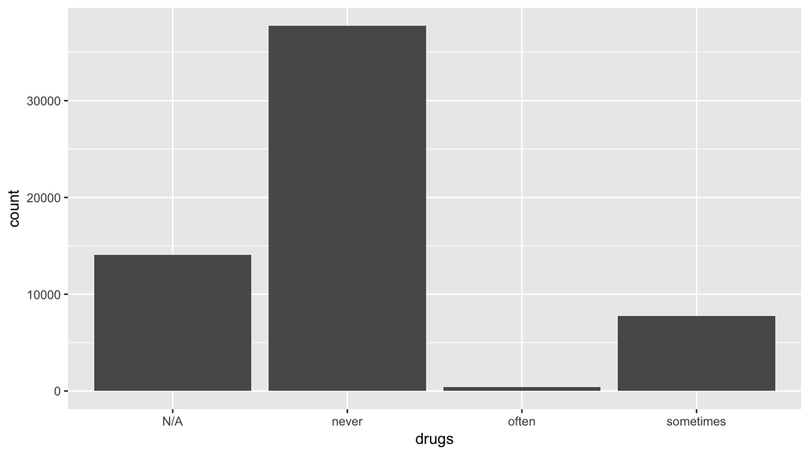

```r
ggplot(data=profiles, aes(x=drugs)) +
  geom_bar()
```

**c)** Create a visualization that shows the same information as in part a), but for men and women separately. Who is more likely to say they never use drugs? Men or women?

**Solution:** We plot the raw counts of drug use split by sex. However, we can’t compare these values directly because the population involves 35,829 males and 24,117 females as we saw above!

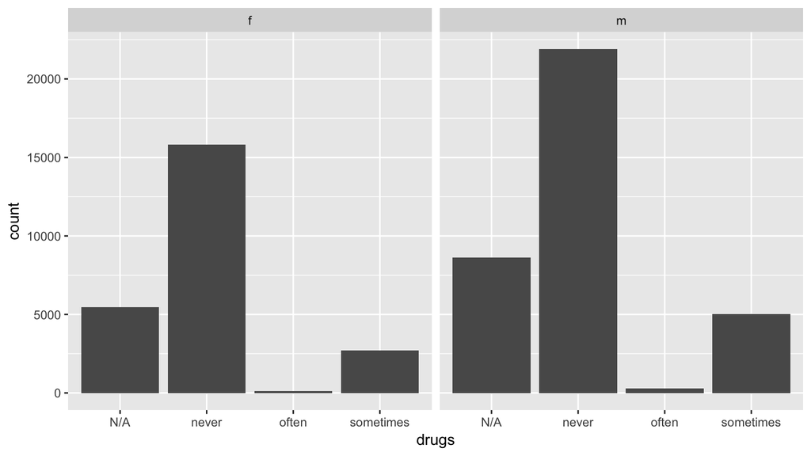

```r
ggplot(data=profiles, aes(x=drugs)) +
  geom_bar() +
  facet_wrap(~sex)
```

**Advanced**: So instead we must normalize to proportions. Note this was not expected of you for this problem set at the time, but we are now in a position to understand it. Here we `group_by` both `sex` and `drugs`, get counts, and compute proportions, we change the `group_by()` structure, and then instead of summarizing, we mutate to compute a proportion. Ask yourself, what values sum to 1?

```r
proportions <- profiles %>%
  group_by(sex, drugs) %>%
  summarise(count = n()) %>%
  group_by(sex) %>%
  mutate(proportion = count/sum(count)) %>%
  mutate(proportion = round(proportion, 2))
proportions
```

| sex | drugs | count | proportion |
| --- | --- | --- | --- |
| f | N/A | 5465 | 0.23 |
| f | never | 15829 | 0.66 |
| f | often | 128 | 0.01 |
| f | sometimes | 2695 | 0.11 |
| m | N/A | 8615 | 0.24 |
| m | never | 21895 | 0.61 |
| m | often | 282 | 0.01 |
| m | sometimes | 5037 | 0.14 |

Now let’s try to plot it. Recall when we covered barplots, we saw there are two cases of barplots:

1. Where the counts are not pre-computed. what we’ve been using
2. Where the counts are pre-computed. This case.

We map the `proportion` to the `y` aesthetic. But for this to work, we need to add a note to `geom_bar()` that we are specifying a `y` aesthetic by setting `geom_bar(stat="identity")`

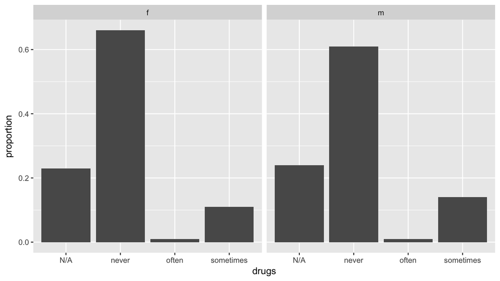

```r
ggplot(data=proportions, aes(x=drugs, y=proportion)) +
  geom_bar(stat="identity") +
  facet_wrap(~sex)
```

We now see that it is women who are more likely to self report that they never use drugs.

**d)** After we loaded the data above via `data(profiles)`, we made sure to convert all missing values, encoded in R as `NA`, to a specific response `N/A` i.e. not answered. Why do you think it was important to do so?

**Solution:** Given the nature of the variable, some people might not be willing to answer. It is important not to ignore these people or we might **bias** the results.

## Question 2: Gapminder

We’re going revisit the Gapminder data from PS-05. Run this code first:

```r
library(gapminder)
data(gapminder)
```

**a)** Output a table that shows the mean and median GDP of all countries in the year 2007, but split by continent. Your table should be 5 rows and 3 columns.

```r
mean_median_GDP_by_continent <- gapminder %>%
  filter(year==2007) %>%
  select(continent, gdpPercap) %>%
  group_by(continent) %>%
  summarise(
    mean_GDP_per_capita = mean(gdpPercap),
    median_GDP_per_capita = median(gdpPercap)
  )
mean_median_GDP_by_continent
```

| continent | mean_GDP_per_capita | median_GDP_per_capita |
| --- | --- | --- |
| Africa | 3089.033 | 1452.267 |
| Americas | 11003.032 | 8948.103 |
| Asia | 12473.027 | 4471.062 |
| Europe | 25054.482 | 28054.066 |
| Oceania | 29810.188 | 29810.188 |

## Question 3: Titanic

Let’s study data relating to who survived the Titanic disaster. Run this code first:

```r
data(Titanic)
# Convert the Titanic data to data frame format
Titanic <- Titanic %>%
  tbl_df()
```

**a)** Output tables that compares survivor counts

1. between men and women
2. betweent the different classes

**Solution:** Let’s first look at the `Titanic` data

```r
Titanic
```

| Class | Sex | Age | Survived | n |
| --- | --- | --- | --- | --- |
| 1st | Male | Child | No | 0 |
| 2nd | Male | Child | No | 0 |
| 3rd | Male | Child | No | 35 |
| Crew | Male | Child | No | 0 |
| 1st | Female | Child | No | 0 |
| 2nd | Female | Child | No | 0 |
| 3rd | Female | Child | No | 17 |
| Crew | Female | Child | No | 0 |
| 1st | Male | Adult | No | 118 |
| 2nd | Male | Adult | No | 154 |
| 3rd | Male | Adult | No | 387 |
| Crew | Male | Adult | No | 670 |
| 1st | Female | Adult | No | 4 |
| 2nd | Female | Adult | No | 13 |
| 3rd | Female | Adult | No | 89 |
| Crew | Female | Adult | No | 3 |
| 1st | Male | Child | Yes | 5 |
| 2nd | Male | Child | Yes | 11 |
| 3rd | Male | Child | Yes | 13 |
| Crew | Male | Child | Yes | 0 |
| 1st | Female | Child | Yes | 1 |
| 2nd | Female | Child | Yes | 13 |
| 3rd | Female | Child | Yes | 14 |
| Crew | Female | Child | Yes | 0 |
| 1st | Male | Adult | Yes | 57 |
| 2nd | Male | Adult | Yes | 14 |
| 3rd | Male | Adult | Yes | 75 |
| Crew | Male | Adult | Yes | 192 |
| 1st | Female | Adult | Yes | 140 |
| 2nd | Female | Adult | Yes | 80 |
| 3rd | Female | Adult | Yes | 76 |
| Crew | Female | Adult | Yes | 20 |

We see that the variable `n` reports the **pre-computed** count of passengers for each `Class`, `Sex`, `Age`, `Survived` category. The key difficulty of this question was distiguising between using `n()` to count observations vs `sum()`. Here, we need to `sum(n)`:

```r
survival_by_sex <- Titanic %>%
  group_by(Sex, Survived) %>%
  summarise(n=sum(n))
survival_by_sex
```

| Sex | Survived | n |
| --- | --- | --- |
| Female | No | 126 |
| Female | Yes | 344 |
| Male | No | 1364 |
| Male | Yes | 367 |

```r
survival_by_class <- Titanic %>%
  group_by(Class, Survived) %>%
  summarise(n=sum(n))
survival_by_class
```

| Class | Survived | n |
| --- | --- | --- |
| 1st | No | 122 |
| 1st | Yes | 203 |
| 2nd | No | 167 |
| 2nd | Yes | 118 |
| 3rd | No | 528 |
| 3rd | Yes | 178 |
| Crew | No | 673 |
| Crew | Yes | 212 |

**b)** For each comparison above, indicate who was most likely to survive.

- `Survival` by `Sex`: Female survival 344/(344+126) = 73.2%, Male survival 367/(367+1362) = 21.2%. Women were much more likely to survive.
- `Survival` by `Class`: 1st class was most likely to survive at 62.5%

**Advanced**: convert to proportions

```r
survival_by_class_prop <- Titanic %>%
  group_by(Class, Survived) %>%
  summarise(n=sum(n)) %>%
  group_by(Class) %>%
  mutate(proportion = n/sum(n)) %>%
  mutate(proportion = round(proportion, 3))
survival_by_class_prop
```

| Class | Survived | n | proportion |
| --- | --- | --- | --- |
| 1st | No | 122 | 0.375 |
| 1st | Yes | 203 | 0.625 |
| 2nd | No | 167 | 0.586 |
| 2nd | Yes | 118 | 0.414 |
| 3rd | No | 528 | 0.748 |
| 3rd | Yes | 178 | 0.252 |
| Crew | No | 673 | 0.760 |
| Crew | Yes | 212 | 0.240 |

# Problem Set 05

Load needed packages:

```r
library(ggplot2)
library(dplyr)
library(fivethirtyeight)
library(Quandl)
library(lubridate)
library(tidyr)
```

## Question 1: Bechdel Test

**a)** What is the Bechdel test? Hint: Read the first three paragraphs of the news article linked in the help file for the bechdel data set.

**b)** The following bit of code takes the bechdel data set, limits to movies made in 1972 or later, and for each year reports the proportion of movies where binary is equal to PASS. Run this code (such code is the focus of Chapter 5: Data Wrangling):

```r
bechdel_cleaned <- bechdel %>%
  select(year, binary) %>%
  filter(year >= 1972) %>%
  group_by(year) %>%
  summarize(prop_pass_bechdel=sum(binary=="PASS")/n())
```

After `View()`’ing the data, create an appropriate plot that shows the time trend of the proportion of movies that pass the Bechdel test. Write your code here:

**c)** What can you tell someone who asks “What is the state of female representation” in movies?

### Discussion

**a)** For any of the data sets in the `fivethirtyeight` package, the help file lists information. For example: `?bechdel`. The Bechdel test is:

1. Are there at least two named women in the movie?
2. Do they have a conversation with each other at some point?
3. Does that conversation involve something other than a male character??

**b)** Notice how we computed the propotion using `group_by()`, `summarize()`, and the `n()` summary/many-to-one function. Also note I forgot to erase the solution to this question, so let me make the plot a little fancier:

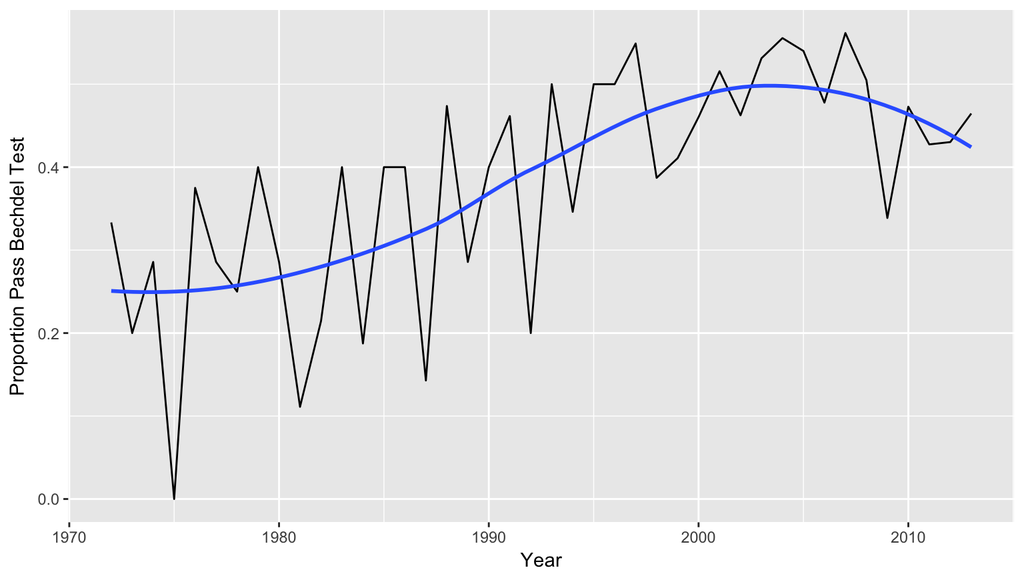

```r
ggplot(bechdel_cleaned, aes(x=year, y=prop_pass_bechdel)) +
  geom_line() +
  labs(x="Year", y="Proportion Pass Bechdel Test",
       "Proportion of Movies that Pass Bechdel Test over Time") +
  geom_smooth(se=FALSE)
```

`geom_smooth()` adds a **smoother** line, `se=FALSE` suppresses the error bars ( try `geom_smooth()` by itself where `se` is set to TRUE by default to see difference). This picks out the **signal** from the **noise**.

**c)** Many possible answers here. In my opinion, there has been an increases since the 1970’s in movies that pass Bechdel, but of late things seem to have leveled off at about 50%.

## Question 2: Cheese and Milk Production

Run the code below. It will create a data frame food contains cheese and milk production in the United States for every year since 1925. See these links for more info:

- https://www.quandl.com/data/USDANASS/NASS_CHEESEPRODUCTIONMEASUREDINLB
- https://www.quandl.com/data/NASS_MILKPRODUCTIONMEASUREDINLB

```r
cheese <-
  Quandl("USDANASS/NASS_CHEESEPRODUCTIONMEASUREDINLB", start_date="1925-01-01") %>%
  mutate(type="cheese", date=ymd(Date), value=Value) %>%
  select(type, date, value)
milk <-
  Quandl("USDANASS/NASS_MILKPRODUCTIONMEASUREDINLB", start_date="1925-01-01") %>%
  mutate(type="milk", date=ymd(Date), value=Value) %>%
  select(type, date, value)
food <- bind_rows(cheese, milk) %>%
  tbl_df()
```

**a)** Between cheese and milk, relatively speaking, which agricultural good has seen the bigger overall increases in production? Write your code below:

### Discussion

At first glance, it seems milk made the biggest gains:

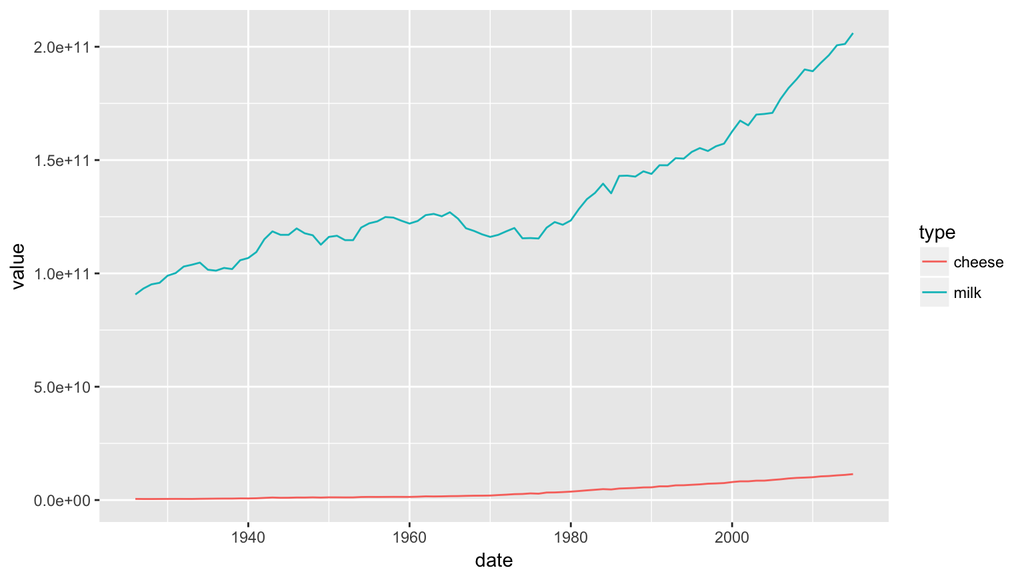

```r
ggplot(data=food, aes(x=date, y=value, col=type)) +
  geom_line()
```

But the above plot is of little use since the scale of milk prices is making it difficult to see any differences in the price of cheese. Let’s plot them separately.

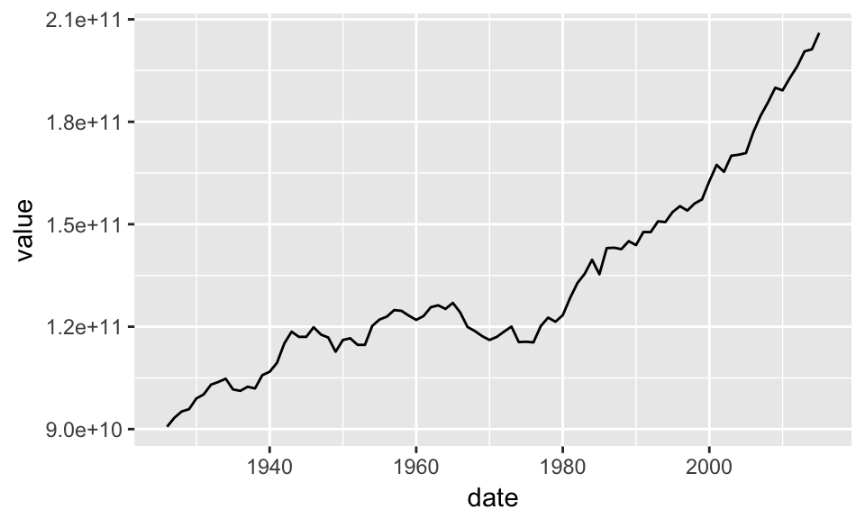

```r
# Write your code below:
ggplot(data=milk, aes(x=date, y=value)) +
  geom_line()
```

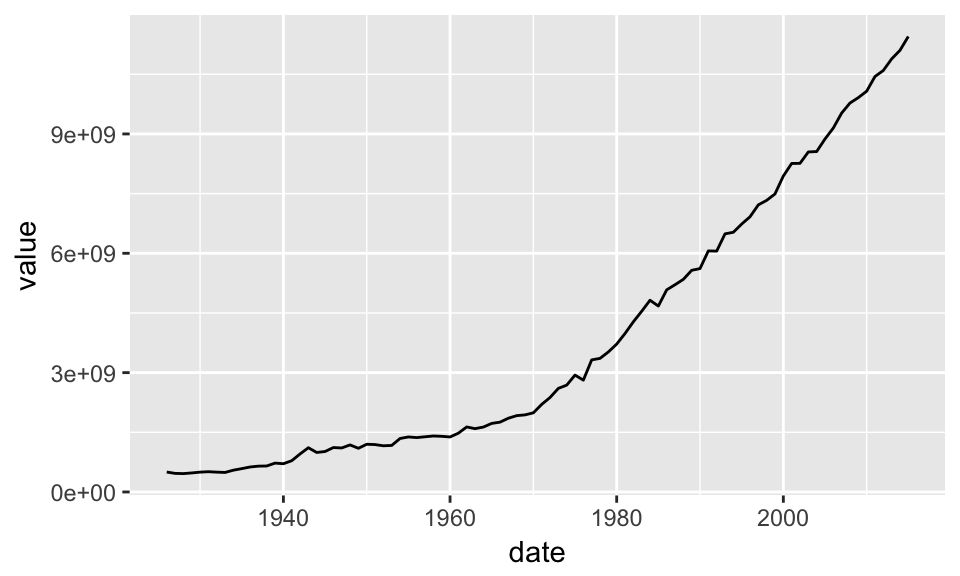

```r
ggplot(data=cheese, aes(x=date, y=value)) +
  geom_line()
```

Both trend up, but which had the biggest relative increases i.e. which had the **highest percent increase**?

$$\text{Percent difference} = \frac{\text{Price in 2015} - \text{Price in 1925}}{\text{Price in 1925}} \times 100 \%$$

| Food Type | 1925 | 2014 | Absolute Change | % Change |
| --- | --- | --- | --- | --- |
| milk | 90,699,000,000 | 206,046,000,000 | 115,347,000,000 | 127.18% |
| cheese | 501,096,000 | 11,450,117,000 | 10,949,021,000 | 2185.01% |

Cheese wins by a landslide. 2100% increase.

## Question 3: Histogram

**a)** Recreate the histogram in Question 2 of the midterm using the following data:

```r
example <- data_frame(
  x = c(rep(3, 1), rep(4, 4), rep(5, 10), rep(6, 4), rep(7, 1), rep(3:7, each=4)),
  group = c(rep(1, 20), rep(2, 20))
)
```

### Solution

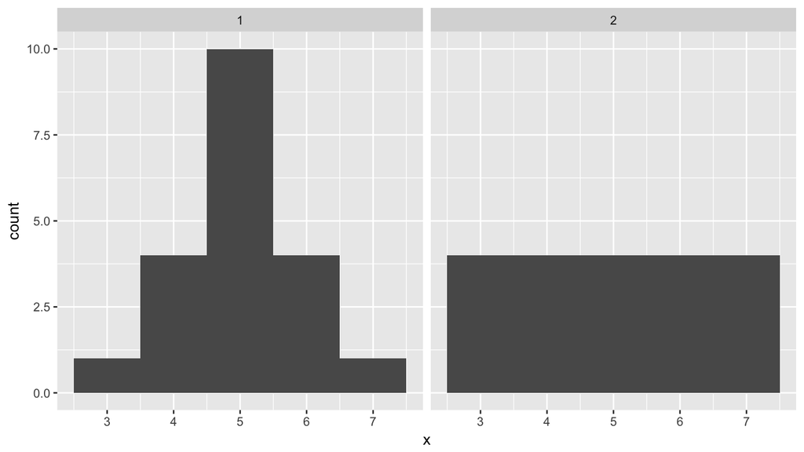

```r
ggplot(data=example, aes(x=x)) +
  geom_histogram(bins=5) +
  facet_wrap(~group)
```

We could’ve also done `geom_histogram(binwidth=1)`

## Question 4: Drinks

Let’s look at the data set drinks from the `fivethirtyeight` package.

```r
data(drinks)
```

**a)** Which 3 countries drink the most total alcohol according to this data?

**b)** The following bit of code uses the `gather()` function from the `tidyr` package to convert the data to tidy format and then arranges it by country. Do Question 3.b) from the midterm using another `geom` besides `boxplot`.

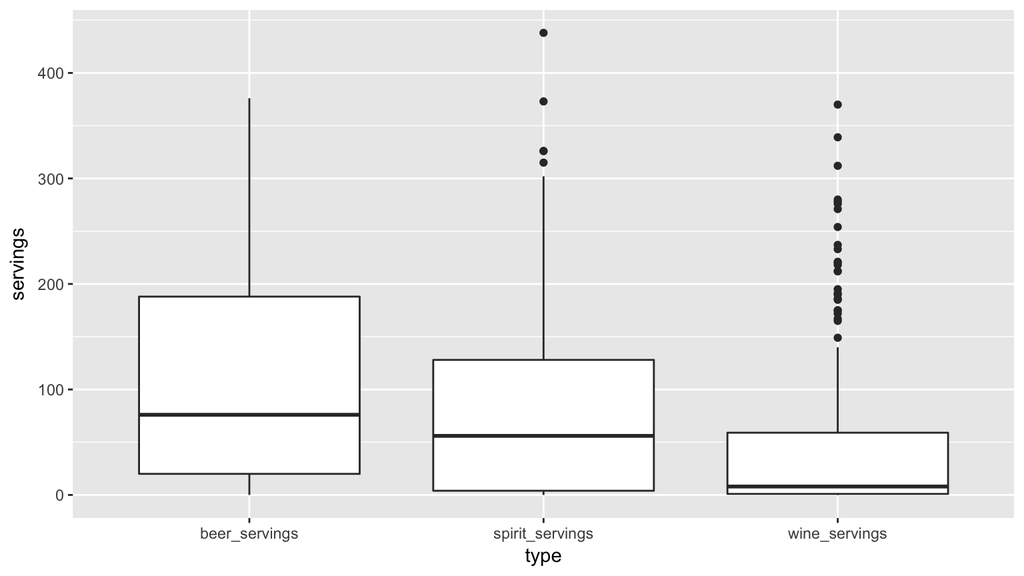

```r
drinks_tidy <- drinks %>%
  gather(type, servings, -c(country, total_litres_of_pure_alcohol)) %>%
  arrange(country)

ggplot(data=drinks_tidy, aes(x=type, y=servings)) +
  geom_boxplot()
```

**c)** What type of alcoholic beverage is the most consumed on earth?

### Discussion

**a)** The easiest way to do this is to use `View(drinks)` and play with the sorting arrows: Belarus, then Lithuania, then Andorra.

**b)** We really want to emphasize the **beer vs spirits vs wine** comparison of the numerical variable `servings` above all:

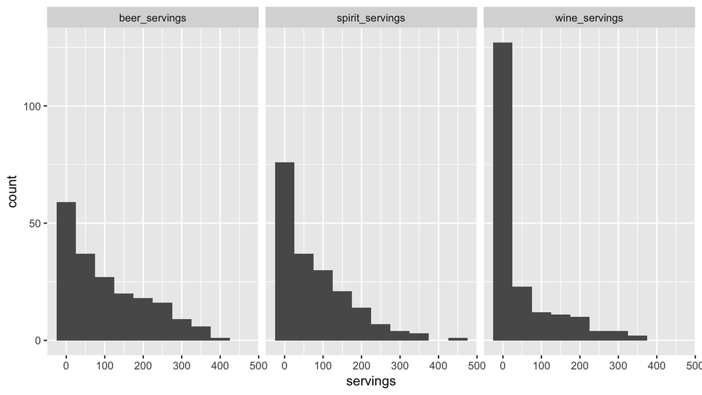

```r
ggplot(data=drinks_tidy, aes(x=servings)) +
  geom_histogram(binwidth = 50) +
  facet_wrap(~type)
```

**c)** In my opinion, this question is best answered using the boxplot: Overall beer seems to be the most popular in terms of servings.

## BONUS

In the TED talk [The best stats you’ve ever seen](https://www.ted.com/talks/hans_rosling_shows_the_best_stats_you_ve_ever_seen) Hans Rosling (RIP 2017) presents human and international development data. The data seen in the video is accessible in the gapminder data set within the gapminder package:

```r
library(gapminder)
data(gapminder)
```

The next bit of code

- Filters the data set to only consider observations for two years: 1952 & 2007
- Renames the “pop” variable to “population”

```r
gapminder <-
  filter(gapminder, year==1952 | year==2007) %>%
  rename(population=pop)
```

**a)** Recreate the scatterplot of “Child Survival (%)” over “GDP per capita ($)” seen at 12:00 in the video, but

- Making a comparison between 1952 and 2007
- Displaying “life expectancy” instead of “Child Survival”

Do so by changing the code snippet below:

```r
ggplot(data=DATASETNAME, aes(AES1=VAR1, AES2=VAR2, AES3=VAR3, AES4=VAR4)) +
  geom_point() +
  facet_wrap(~VAR5) +
  scale_x_log10() +
  labs(x="WRITE INFORMATIVE LABEL HERE", y="WRITE INFORMATIVE LABEL HERE", title="WRITE INFORMATIVE TITLE HERE")
```

**b)** Describe two facts that would be of interest to international development organizations.

### Discussion

**a)**

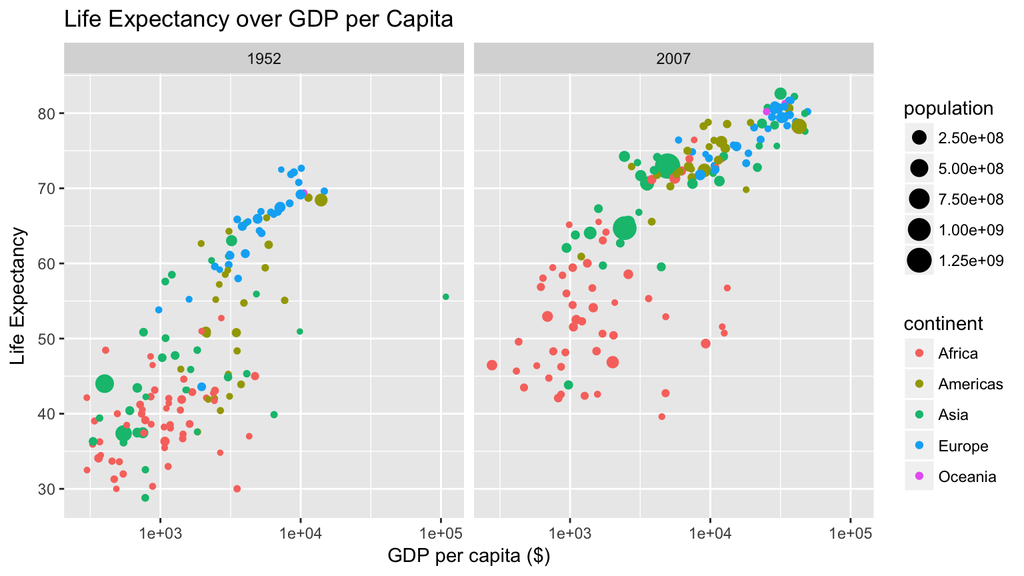

```r
ggplot(data=gapminder, aes(x=gdpPercap, y=lifeExp, size=population, col=continent)) +
  geom_point() +
  facet_wrap(~year) +
  scale_x_log10() +
  labs(x="GDP per capita ($)", y="Life Expectancy", title="Life Expectancy over GDP per Capita")
```

**b)** In my opinion

- Overall, there have been gains in both GDP per capita and life expectancy between 1952 and 2007
- However, broken down by continent:
  - Europe and the Americas have seen modest gains
  - Asia has made massive gains
  - Unfortunately Africa still lags behind

# Problem Set 03

Load needed packages:

```r
library(ggplot2)
library(dplyr)
```

## Question 1: Movie Ratings

The `movies` data set in the `ggplot2movies` package has information and ratings on 28,819 movies. This many data points is a bit unwieldy, so let’s take a random sample of 1000 of these movies. Furthermore, let’s take the variable `Comedy` and convert it to a `yes` vs `no` (binary) categorical variable. Note: you don’t need to understand this code for now, we’ll see this when we study data manipulation in Chapter 5.

```r
library(ggplot2movies)
data(movies)
movies <- movies %>%
  sample_n(1000) %>%
  mutate(Comedy=ifelse(Comedy==1, "yes", "no"))
```

1. You want to know for these 1000 randomly chosen movies: What is the relationship between the year the movie was made and the IMDB rating? Furthermore, I want to distinguish between comedies and non-comedies. In the code block below, write the code that generates a graphic that will answer this for you. Write your code here:

### Discussion

1. Comedy is a categorical variable we can split on by assigning a color to

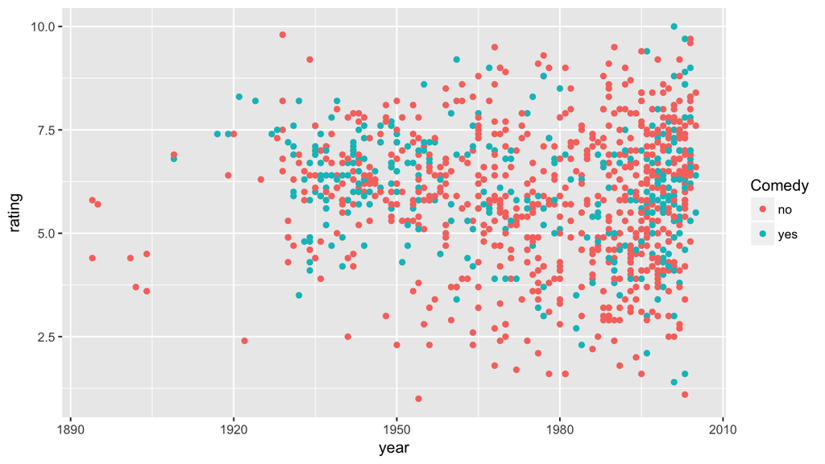

```r
ggplot(data=movies, aes(x=year, y=rating, color=Comedy)) +
  geom_point()
```

2. This is very hard to eye-ball. We can add a **regression line** for Comedies and Non-Comedies using `geom_smooth()`, which is a kind of `geom_line()`. We’ll see more and more of this as the semester progresses. Is that small difference **statistically significant**? Hard to tell.

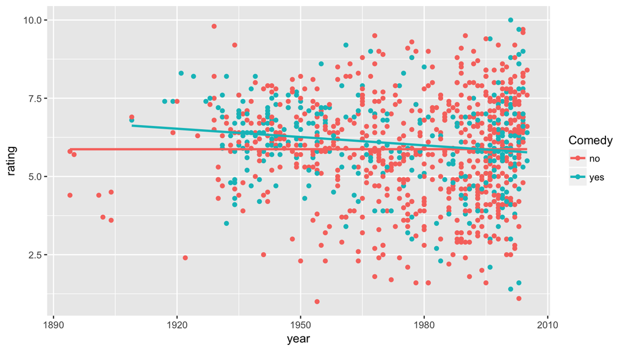

```r
ggplot(data=movies, aes(x=year, y=rating, col=Comedy)) +
  geom_point() +
  geom_smooth(method="lm", se=FALSE)
```

## Question 2: Babynames

Considering the `babynames` data set in the `babynames` package again, we will limit consideration to only the name “Casey”.

```r
library(babynames)
data(babynames)
babynames <- babynames %>%
  filter(name=="Casey")
```

1. I want to know about popularity trends of the name “Casey” as a male name and as a female name over the years. In the code block below, write the code that generates a graphic that will answer this for you. Write your code here:
2. Given this graphic, what can you say about the name “Casey”? Don’t merely describe elements on graphic, but make a broader statement. For example, what would you tell a parent who is interested in naming their child “Casey”?

### Discussion

1. While we could’ve made separate plots, its easier to view things on the same plot:

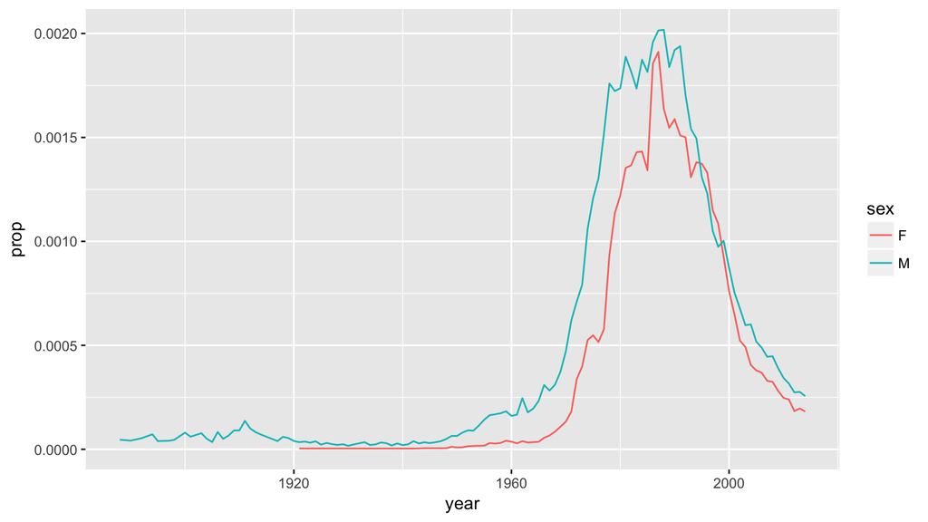

```r
ggplot(data=babynames, aes(x=year, y=prop, col=sex)) +
  geom_line()
```